# Modeling with tidymodels in R - Chapter 03

Prof. Edneide Ramalho

29/07/2023

[figure not shown]

# 1 Imports

```r
library(tidyverse)
library(tidymodels)
```

# 2 Feature Engineering

We are going to use the `recipe()` package.

https://recipes.tidymodels.org/reference/index.html

## 2.1 Simple feature engineering pipeline

```r
# data
leads_df <- readRDS('datasets/leads_df.rds')
```

## 2.2

Building a recipe object

Let’s apply the step_log on the total_time variable:

```r
leads_log_rec <- recipe(purchased ~ .,
                        data = leads_df) %>%
  step_log(total_time, base = 10)

leads_log_rec
```

## 2.3 Explore variables roles and types

```r
leads_log_rec %>%
  summary()
```

| variable | type | role | source |
| --- | --- | --- | --- |
| total_visits |  | predictor | original |
| total_time |  | predictor | original |
| pages_per_visit |  | predictor | original |
| total_clicks |  | predictor | original |
| lead_source |  | predictor | original |
| us_location |  | predictor | original |
| purchased |  | outcome | original |

## 2.4 Training a recipe object

```r
# Split
leads_training <- leads_df %>%
  initial_split(prop = 0.75) %>%
  training()

leads_test <- leads_df %>%
  initial_split(prop = 0.75) %>%
  testing()
```

```r
leads_log_rec_prep <- leads_log_rec %>%
  prep(training = leads_training)

leads_log_rec_prep
```

## 2.5 Transforming the training object

- By default, transformed data is retained by `prep()` function.
- Pass `NULL` to `new_data` to extract
- Return a tibble with transformed data

```r
leads_log_rec_prep %>%
  bake(new_data = NULL)
```

| total_visits | total_time | pages_per_visit | total_clicks | lead_source | us_location | purchased |
| --- | --- | --- | --- | --- | --- | --- |
| 5 | 2.7209857 | 1.67 | 22 | organic_search | west | no |
| 2 | 1.7160033 | 2.00 | 22 | direct_traffic | southeast | no |
| 8 | 1.1461280 | 8.00 | 63 | organic_search | west | no |
| 9 | 3.0077478 | 3.00 | 25 | email | midwest | yes |
| 2 | 2.5237465 | 2.00 | 18 | organic_search | west | no |
| 13 | 1.7923917 | 2.17 | 23 | email | southwest | no |
| 4 | 2.5965971 | 2.00 | 22 | affiliate | northeast | no |
| 3 | 2.3729120 | 1.50 | 13 | direct_traffic | southeast | no |
| 2 | 2.5198280 | 2.00 | 15 | email | southwest | no |
| 2 | 3.0441476 | 2.00 | 17 | email | southeast | no |

[output cut: 986 more lines]

```r
leads_log_rec_prep %>%
  bake(new_data = NULL)
```

| total_visits | total_time | pages_per_visit | total_clicks | lead_source | us_location | purchased |
| --- | --- | --- | --- | --- | --- | --- |
| 5 | 2.7209857 | 1.67 | 22 | organic_search | west | no |
| 2 | 1.7160033 | 2.00 | 22 | direct_traffic | southeast | no |
| 8 | 1.1461280 | 8.00 | 63 | organic_search | west | no |
| 9 | 3.0077478 | 3.00 | 25 | email | midwest | yes |
| 2 | 2.5237465 | 2.00 | 18 | organic_search | west | no |
| 13 | 1.7923917 | 2.17 | 23 | email | southwest | no |
| 4 | 2.5965971 | 2.00 | 22 | affiliate | northeast | no |
| 3 | 2.3729120 | 1.50 | 13 | direct_traffic | southeast | no |
| 2 | 2.5198280 | 2.00 | 15 | email | southwest | no |
| 2 | 3.0441476 | 2.00 | 17 | email | southeast | no |

[output cut: 986 more lines]

## 2.6 Transforming new data

```r
leads_log_rec_prep %>%
  bake(new_data = leads_test)
```

| total_visits | total_time | pages_per_visit | total_clicks | lead_source | us_location | purchased |
| --- | --- | --- | --- | --- | --- | --- |
| 3 | 2.2201081 | 3.00 | 32 | direct_traffic | southeast | no |
| 2 | 2.3710679 | 1.00 | 13 | organic_search | southeast | no |
| 3 | 2.2455127 | 3.00 | 27 | organic_search | west | no |
| 5 | 2.7604225 | 5.00 | 42 | email | west | yes |
| 2 | 2.0293838 | 2.00 | 18 | direct_traffic | southeast | yes |
| 4 | 2.2718416 | 2.00 | 21 | organic_search | southeast | no |
| 2 | 0.9542425 | 2.00 | 25 | email | west | yes |
| 2 | 3.1513699 | 2.00 | 23 | direct_traffic | midwest | no |
| 5 | 2.9818186 | 2.50 | 28 | email | northeast | yes |
| 3 | 2.2787536 | 1.50 | 14 | direct_traffic | midwest | no |

[output cut: 322 more lines]

## 2.7 Exercises - Part 1

```r
# data
telecom_df <- readRDS('datasets/telecom_df.rds')
glimpse(telecom_df)
```

```
## Rows: 975
## Columns: 9
## $ canceled_service    <fct> yes, yes, no, yes, no, no, yes, no, yes, no, yes, …
## $ cellular_service    <fct> single_line, single_line, single_line, multiple_li…
## $ avg_data_gb         <dbl> 7.78, 9.04, 10.32, 5.08, 8.05, 9.30, 8.01, 9.40, 5…
## $ avg_call_mins       <dbl> 497, 336, 262, 250, 328, 326, 525, 312, 417, 340, …
## $ avg_intl_mins       <dbl> 127, 88, 55, 107, 122, 114, 97, 147, 96, 136, 88, …
## $ internet_service    <fct> fiber_optic, fiber_optic, fiber_optic, digital, di…
## $ contract            <fct> month_to_month, month_to_month, one_year, one_year…
## $ months_with_company <dbl> 7, 10, 50, 53, 50, 25, 19, 50, 8, 61, 45, 33, 17, …
## $ monthly_charges     <dbl> 76.45, 94.90, 103.05, 60.05, 75.15, 95.70, 83.65, …
```

> 1. **Exploring recipe objects**

The first step in feature engineering is to specify a `recipe` object with the `recipe()` function and add data preprocessing steps with one or more `step_*()` functions. Storing all of this information in a single `recipe` object makes it easier to manage complex feature engineering pipelines and transform new data sources.

Use the R console to explore a `recipe` object named `telecom_rec`, which was specified using the `telecom_training` data from the previous chapter and the code below.

```
telecom_rec <- recipe(canceled_service ~ .,
                      data = telecom_df) %>%
  step_log(avg_call_mins, base = 10)
```

Both `telecom_training` and `telecom_rec` have been loaded into your session.

How many numeric and nominal predictor variables are encoded in the `telecom_rec` object?

```r
telecom_rec <- recipe(canceled_service ~ .,
                      data = telecom_df) %>%
  step_log(avg_call_mins, base = 10)

telecom_rec

telecom_rec %>%
  summary() %>%
  filter(role == 'predictor') %>%
  separate(type, into = c("type1", "type2", "type3")) %>%
  select(-type1) %>%
  group_by(type2) %>%
  summarise(n = n())
```

| type2 | n |
| --- | --- |
| double | 5 |
| factor | 3 |

- 5 numerical variables and 3 categorical variables.

> **2. Creating recipe objects**

In the previous chapter, you fit a logistic regression model using a subset of the predictor variables from the `telecom_df` data. This dataset contains information on customers of a telecommunications company and the goal is predict whether they will cancel their service.

In this exercise, you will use the `recipes` package to apply a log transformation to the `avg_call_mins` and `avg_intl_mins` variables in the telecommunications data. This will reduce the range of these variables and potentially make their distributions more symmetric, which may increase the accuracy of your logistic regression model.

- Create a `recipe` object, `telecom_log_rec`, that uses `canceled_service` as the outcome variable and all remaining columns in `telecom_training` as predictor variables.
- Add a step to the `recipe` object that will log transform `avg_call_mins` and `avg_intl_mins`.
- View the variable roles and data types that were assigned by the `recipe()` function in the `telecom_log_rec` object.

  ```r
  # Split data into training and test datasets
  telecom_training <- initial_split(telecom_df,
                                    prop = 0.75) %>%
    training()

  telecom_test <- initial_split(telecom_df,
                                    prop = 0.75) %>%
    testing()

  # Specify feature engineering recipe
  telecom_log_rec <- recipe(canceled_service ~ .,
                            data = telecom_training) %>%
    # Add log transformation step
    step_log(avg_call_mins, avg_intl_mins, base = 10)

  # View variable roles and data types
  telecom_log_rec %>%
    summary()
  ```

  | variable | type | role | source |
  | --- | --- | --- | --- |
  | cellular_service |  | predictor | original |
  | avg_data_gb |  | predictor | original |
  | avg_call_mins |  | predictor | original |
  | avg_intl_mins |  | predictor | original |
  | internet_service |  | predictor | original |
  | contract |  | predictor | original |
  | months_with_company |  | predictor | original |
  | monthly_charges |  | predictor | original |
  | canceled_service |  | outcome | original |

> 3. **Training a recipe object**

In the previous exercise, you created a `recipe` object with instructions to apply a log transformation to the `avg_call_mins` and `avg_intl_mins` predictor variables in the telecommunications data.

The next step in the feature engineering process is to train your `recipe` object using the training data. Then you will be able to apply your trained `recipe` to both the training and test datasets in order to prepare them for use in model fitting and model evaluation.

Your `recipe` object, `telecom_log_rec`, and the `telecom_training` and `telecom_test` datasets have been loaded into your session.

  ```r
  # Train the telecom_log_rec object
  telecom_log_rec_prep <- telecom_log_rec %>%
    prep(training = telecom_training)

  # View results
  telecom_log_rec_prep
  ```

- Use your trained `recipe` to obtain the transformed training dataset.

  ```r
  # Apply to training data
  telecom_log_rec_prep %>%
    bake(new_data = NULL)
  ```

  | cellular_service | avg_data_gb | avg_call_mins | avg_intl_mins | internet_service | contract | months_with_company | monthly_charges | canceled_service |
  | --- | --- | --- | --- | --- | --- | --- | --- | --- |
  | single_line | 7.29 | 2.578639 | 2.120574 | fiber_optic | month_to_month | 13 | 70.15 | no |
  | multiple_lines | 8.71 | 2.572872 | 2.012837 | fiber_optic | month_to_month | 18 | 95.05 | no |
  | single_line | 7.18 | 2.397940 | 2.127105 | fiber_optic | month_to_month | 1 | 70.85 | yes |
  | single_line | 8.91 | 2.639486 | 1.602060 | fiber_optic | month_to_month | 1 | 89.90 | yes |
  | single_line | 7.96 | 2.518514 | 1.707570 | fiber_optic | month_to_month | 1 | 79.05 | yes |
  | multiple_lines | 10.72 | 2.642465 | 1.681241 | fiber_optic | one_year | 70 | 104.80 | no |
  | single_line | 11.36 | 2.484300 | 2.008600 | fiber_optic | two_year | 72 | 111.95 | no |
  | single_line | 7.98 | 2.460898 | 2.075547 | fiber_optic | month_to_month | 2 | 74.95 | no |
  | single_line | 6.88 | 2.611723 | 1.838849 | fiber_optic | month_to_month | 32 | 74.40 | yes |
  | multiple_lines | 8.11 | 2.487138 | 2.110590 | digital | two_year | 72 | 88.05 | no |

  [output cut: 721 more lines]

- Apply your trained `recipe` to the test dataset.

```r
# Apply to test data
telecom_log_rec_prep %>%
  bake(new_data = telecom_test)
```

| cellular_service | avg_data_gb | avg_call_mins | avg_intl_mins | internet_service | contract | months_with_company | monthly_charges | canceled_service |
| --- | --- | --- | --- | --- | --- | --- | --- | --- |
| single_line | 10.32 | 2.418301 | 1.740363 | fiber_optic | one_year | 50 | 103.05 | no |
| single_line | 9.37 | 2.582063 | 1.939519 | fiber_optic | month_to_month | 4 | 94.90 | no |
| single_line | 8.67 | 2.577492 | 2.037426 | fiber_optic | month_to_month | 26 | 88.80 | yes |
| single_line | 7.31 | 2.390935 | 2.075547 | digital | one_year | 58 | 75.20 | no |
| multiple_lines | 6.79 | 2.710963 | 2.149219 | digital | one_year | 12 | 74.05 | yes |
| single_line | 6.19 | 2.285557 | 1.913814 | digital | one_year | 14 | 59.10 | no |
| single_line | 7.96 | 2.518514 | 1.707570 | fiber_optic | month_to_month | 1 | 79.05 | yes |
| multiple_lines | 9.23 | 2.539076 | 2.123852 | fiber_optic | month_to_month | 30 | 94.10 | yes |
| multiple_lines | 5.37 | 2.525045 | 2.230449 | digital | month_to_month | 44 | 50.15 | no |
| single_line | 10.69 | 2.488551 | 1.954243 | fiber_optic | two_year | 70 | 101.00 | no |

[output cut: 234 more lines]

# 3 Numeric predictors

## 3.1 Exercises - Part 2

> 1. **Discovering correlated predictors**

Correlated predictor variables provide redundant information and can negatively impact the model fitting process. When two variables are highly correlated, their values change linearly with each other and hence provide the same information to your machine learning algorithms. This phenomenon is know as multicollinearity.

Before beginning the model fitting process, it’s important to explore your dataset to uncover these relationships and remove them in your feature engineering steps.

In this exercise, you will explore the `telecom_training` dataset by creating a correlation matrix of all the numeric predictor variables.

- Select all of the numeric columns in the `telecom_training` data.
- Create a correlation matrix of the numeric columns of `telecom_training`.

```r
telecom_training %>%
  # Select numeric columns
  select_if(is.numeric) %>%
  # Calculate correlation matrix
  cor()
```

```
##                     avg_data_gb avg_call_mins avg_intl_mins months_with_company
## avg_data_gb           1.0000000    0.18527707    0.16167246          0.42539999
## avg_call_mins         0.1852771    1.00000000    0.07356337          0.03320671
## avg_intl_mins         0.1616725    0.07356337    1.00000000          0.22746198
## months_with_company   0.4254000    0.03320671    0.22746198          1.00000000
## monthly_charges       0.9558766    0.18150613    0.16578729          0.45001734
##                     monthly_charges
## avg_data_gb               0.9558766
## avg_call_mins             0.1815061
## avg_intl_mins             0.1657873
## months_with_company       0.4500173
## monthly_charges           1.0000000
```

> **QUESTION**: Based on your correlation matrix, which variables have the largest correlation?

> **ANSWER**: `avg_data_gb` and `monthly_charges`.
- Create a scatter plot with `avg_data_gb` on the x-axis and `monthly_charges` on the y-axis.
- Add `Monthly Charges vs. Average Data Usage` to the title of your plot.

```r
telecom_training %>%
  # Select numeric columns
  select_if(is.numeric) %>%
  # Calculate correlation matrix
  cor()
```

```
##                     avg_data_gb avg_call_mins avg_intl_mins months_with_company
## avg_data_gb           1.0000000    0.18527707    0.16167246          0.42539999
## avg_call_mins         0.1852771    1.00000000    0.07356337          0.03320671
## avg_intl_mins         0.1616725    0.07356337    1.00000000          0.22746198
## months_with_company   0.4254000    0.03320671    0.22746198          1.00000000
## monthly_charges       0.9558766    0.18150613    0.16578729          0.45001734
##                     monthly_charges
## avg_data_gb               0.9558766
## avg_call_mins             0.1815061
## avg_intl_mins             0.1657873
## months_with_company       0.4500173
## monthly_charges           1.0000000
```

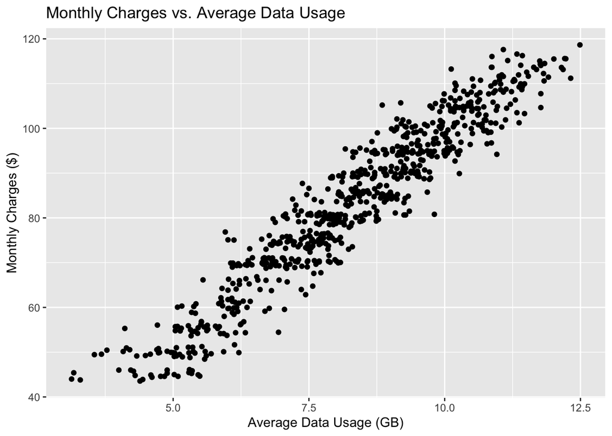

```r
# Plot correlated predictors
ggplot(telecom_training, aes(x = avg_data_gb, y = monthly_charges)) +
  # Add points
  geom_point()  +
  # Add title
  labs(title = 'Monthly Charges vs. Average Data Usage',
       y = 'Monthly Charges ($)', x = 'Average Data Usage (GB)')
```

> 2. **Removing correlated predictors with recipes**

Removing correlated predictor variables from your training and test datasets is an important feature engineering step to ensure your model fitting runs as smoothly as possible.

Now that you have discovered that `monthly_charges` and `avg_data_gb` are highly correlated, you must add a correlation filter with `step_corr()` to your feature engineering pipeline for the telecommunications data.

In this exercise, you will create a `recipe` object that removes correlated predictors from the telecommunications data.

- Create a `recipe` object, `telecom_cor_rec`, that sets the outcome variable to `canceled_service` and all remaining columns in `telecom_training` to predictor variables.
- Add a preprocessing step that removes highly correlated predictor variables using the `all_numeric()` selector function and a correlation threshold of 0.8.
- Train your `telecom_cor_rec` object using the `telecom_training` dataset.
- Use your trained `recipe` to obtain the transformed training dataset.
- Apply your trained `recipe` to the test dataset.

```r
# Specify a recipe object
telecom_cor_rec <- recipe(canceled_service ~ .,
                          data = telecom_training) %>%
  # Remove correlated variables
  step_corr(all_numeric(), threshold = 0.8)

# Train the recipe
telecom_cor_rec_prep <- telecom_cor_rec %>%
  prep(training = telecom_training)

# Apply to training data
telecom_cor_rec_prep %>%
  bake(new_data = NULL)
```

| cellular_service | avg_data_gb | avg_call_mins | avg_intl_mins | internet_service | contract | months_with_company | canceled_service |
| --- | --- | --- | --- | --- | --- | --- | --- |
| single_line | 7.29 | 379 | 132 | fiber_optic | month_to_month | 13 | no |
| multiple_lines | 8.71 | 374 | 103 | fiber_optic | month_to_month | 18 | no |
| single_line | 7.18 | 250 | 134 | fiber_optic | month_to_month | 1 | yes |
| single_line | 8.91 | 436 | 40 | fiber_optic | month_to_month | 1 | yes |
| single_line | 7.96 | 330 | 51 | fiber_optic | month_to_month | 1 | yes |
| multiple_lines | 10.72 | 439 | 48 | fiber_optic | one_year | 70 | no |
| single_line | 11.36 | 305 | 102 | fiber_optic | two_year | 72 | no |
| single_line | 7.98 | 289 | 119 | fiber_optic | month_to_month | 2 | no |
| single_line | 6.88 | 409 | 69 | fiber_optic | month_to_month | 32 | yes |
| multiple_lines | 8.11 | 307 | 129 | digital | two_year | 72 | no |

[output cut: 721 more lines]

```r
# Apply to test data
telecom_cor_rec_prep %>%
  bake(new_data = telecom_test)
```

| cellular_service | avg_data_gb | avg_call_mins | avg_intl_mins | internet_service | contract | months_with_company | canceled_service |
| --- | --- | --- | --- | --- | --- | --- | --- |
| single_line | 10.32 | 262 | 55 | fiber_optic | one_year | 50 | no |
| single_line | 9.37 | 382 | 87 | fiber_optic | month_to_month | 4 | no |
| single_line | 8.67 | 378 | 109 | fiber_optic | month_to_month | 26 | yes |
| single_line | 7.31 | 246 | 119 | digital | one_year | 58 | no |
| multiple_lines | 6.79 | 514 | 141 | digital | one_year | 12 | yes |
| single_line | 6.19 | 193 | 82 | digital | one_year | 14 | no |
| single_line | 7.96 | 330 | 51 | fiber_optic | month_to_month | 1 | yes |
| multiple_lines | 9.23 | 346 | 133 | fiber_optic | month_to_month | 30 | yes |
| multiple_lines | 5.37 | 335 | 170 | digital | month_to_month | 44 | no |
| single_line | 10.69 | 308 | 90 | fiber_optic | two_year | 70 | no |

[output cut: 234 more lines]

> **3. Multiple feature engineering steps**

The power of the `recipes` package is that you can include multiple preprocessing steps in a single `recipe` object. These steps will be carried out in the order they are entered with the `step_*()` functions.

In this exercise, you will build upon your feature engineering from the last exercise. In addition to removing correlated predictors, you will create a `recipe` object that also normalizes all numeric predictors in the telecommunications data.

- Create a `recipe` object, `telecom_norm_rec`, that sets the outcome variable to `canceled_service` and all remaining columns in `telecom_training` to predictor variables.
- Specify your `recipe` to first remove correlated predictors at the 0.8 threshold and then normalize all numeric predictor variables.
- Train your `telecom_norm_rec` object using the `telecom_training` dataset.
- Apply your trained `recipe` to the test dataset.

```r
# Specify a recipe object
telecom_norm_rec <- recipe(canceled_service ~ .,
                          data = telecom_training) %>%
  # Remove correlated variables
  step_corr(all_numeric(), threshold = 0.8) %>%
  # Normalize numeric predictors
  step_normalize(all_numeric())

# Train the recipe
telecom_norm_rec_prep <- telecom_norm_rec %>%
  prep(training = telecom_training)

# Apply to test data
telecom_norm_rec_prep %>%
  bake(new_data = telecom_test)
```

| cellular_service | avg_data_gb | avg_call_mins | avg_intl_mins | internet_service | contract | months_with_company | canceled_service |
| --- | --- | --- | --- | --- | --- | --- | --- |
| single_line | 1.058297958 | -1.15571789 | -1.71781980 | fiber_optic | one_year | 0.609367126 | no |
| single_line | 0.560485804 | 0.41864577 | -0.69011543 | fiber_optic | month_to_month | -1.229507411 | no |
| single_line | 0.193676849 | 0.36616698 | 0.01643132 | fiber_optic | month_to_month | -0.350045676 | yes |
| single_line | -0.518980550 | -1.36563305 | 0.33758893 | digital | one_year | 0.929171393 | no |
| multiple_lines | -0.791467203 | 2.15044579 | 1.04413569 | digital | one_year | -0.909703144 | yes |
| single_line | -1.105874879 | -2.06097699 | -0.85069424 | digital | one_year | -0.829752077 | no |
| single_line | -0.178372234 | -0.26357848 | -1.84628284 | fiber_optic | month_to_month | -1.349434011 | yes |
| multiple_lines | 0.487124013 | -0.05366333 | 0.78720959 | fiber_optic | month_to_month | -0.190143543 | yes |
| multiple_lines | -1.535565369 | -0.19798000 | 1.97549277 | digital | month_to_month | 0.369513925 | no |
| single_line | 1.252182692 | -0.55221182 | -0.59376815 | fiber_optic | two_year | 1.408877794 | no |

[output cut: 234 more lines]

# 4 Nominal predictors

## 4.1 Exercises - Part 3

#### **1. Applying step_dummy() to predictors**

You are using the `telecom_training` data to predict `canceled_service` using `avg_data_gb` and `contract` as predictor variables.

```
| canceled_service | avg_data_gb  | contract         |
| yes              | 7.78         | month_to_month   |
| yes              | 9.04         | month_to_month   |
| yes              | 5.08         | one_year         |
| no               | 8.05         | two_year         |
```

In your feature engineering pipeline, you would like to create dummy variables from the `contract` column and leave `avg_data_gb` and `canceled_service` as is.

Which `step_*()` function from the options will correctly encode your `recipe` object?

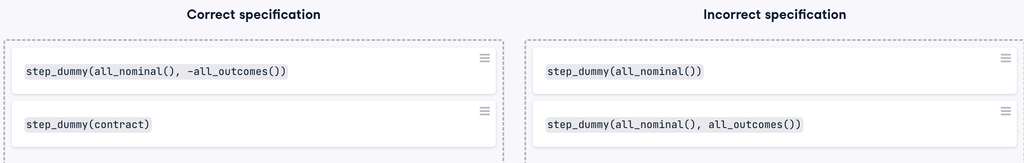

> 2. **Ordering of step_*() functions**

The `step_*()` functions within a recipe are carried out in sequential order. It’s important to keep this in mind so that you avoid unexpected results in your feature engineering pipeline!

In this exercise, you will combine different `step_*()` functions into a single `recipe` and see what effect the ordering of `step_*()` functions has on the final result.

The `telecom_training` and `telecom_test` datasets have been loaded into this session.

- Specify the `telecom_recipe_1` object to normalize all numeric predictors and then create dummy variables for all nominal predictors in the training data, `telecom_training`.
- Select columns **by role** in your `recipe` specification.

```r
telecom_recipe_1 <-
  recipe(canceled_service ~ avg_data_gb + contract, data = telecom_training)  %>%
  # Normalize numeric predictors
  step_normalize(all_numeric())  %>%
  # Create dummy variables for nominal predictors
  step_dummy(all_nominal(), -all_outcomes())
```

- Train `telecom_recipe_1` and use it to transform the test data, `telecom_test`.

```r
# Train and apply telecom_recipe_1 on the test data
telecom_recipe_1 %>%
  prep(training = telecom_training) %>%
  bake(new_data = telecom_test)
```

| avg_data_gb | canceled_service | contract_one_year | contract_two_year |
| --- | --- | --- | --- |
| 1.058297958 | no | 1 | 0 |
| 0.560485804 | no | 0 | 0 |
| 0.193676849 | yes | 0 | 0 |
| -0.518980550 | no | 1 | 0 |
| -0.791467203 | yes | 1 | 0 |
| -1.105874879 | no | 1 | 0 |
| -0.178372234 | yes | 0 | 0 |
| 0.487124013 | yes | 0 | 0 |
| -1.535565369 | no | 0 | 0 |
| 1.252182692 | no | 0 | 1 |

[output cut: 234 more lines]

- Now specify `telecom_recipe_2` to create dummy variables for all nominal predictors and then normalize all numeric predictors in the training data, `telecom_training`.
- Select columns **by role** in your `recipe` specification.
- Train `telecom_recipe_2` and use it to transform the test data, `telecom_test`.

```r
telecom_recipe_2 <-
  recipe(canceled_service ~ avg_data_gb + contract, data = telecom_training)  %>%
  step_dummy(all_nominal(), -all_outcomes()) %>%
  step_normalize(all_numeric(), -all_outcomes())

# Train and apply telecom_recipe_2 on the test data
telecom_recipe_2 %>%
  prep(training = telecom_training) %>%
  bake(new_data = telecom_test)
```

| avg_data_gb | canceled_service | contract_one_year | contract_two_year |
| --- | --- | --- | --- |
| 1.058297958 | no | 1.9667320 | -0.4820754 |
| 0.560485804 | no | -0.5077621 | -0.4820754 |
| 0.193676849 | yes | -0.5077621 | -0.4820754 |
| -0.518980550 | no | 1.9667320 | -0.4820754 |
| -0.791467203 | yes | 1.9667320 | -0.4820754 |
| -1.105874879 | no | 1.9667320 | -0.4820754 |
| -0.178372234 | yes | -0.5077621 | -0.4820754 |
| 0.487124013 | yes | -0.5077621 | -0.4820754 |
| -1.535565369 | no | -0.5077621 | -0.4820754 |
| 1.252182692 | no | -0.5077621 | 2.0715267 |

[output cut: 234 more lines]

# 5 **Complete feature engineering pipeline**

The `recipes` package is designed to encode multiple feature engineering steps into one object, making it easier to maintain data transformations in a machine learning workflow.

In this exercise, you will train a feature engineering pipeline to prepare the telecommunications data for modeling.

The `telecom_df` tibble, as well as your `telecom_training` and `telecom_test` datasets from the previous exercises, have been loaded into your workspace.

- Create a recipe that predicts `canceled_service` using all predictor variables in the training data.
- Remove correlated predictor variables using a 0.8 threshold value.
- Normalize all numeric predictors.
- Create dummy variables for all nominal predictors.
- Train your recipe on the training data and apply it to the test data.

```r
# Create a recipe that predicts canceled_service using the training data
telecom_recipe <- recipe(canceled_service ~ ., data = telecom_training) %>%
  # Remove correlated predictors
  step_corr(all_numeric(), threshold = 0.8) %>%
  # Normalize numeric predictors
  step_normalize(all_numeric()) %>%
  # Create dummy variables
  step_dummy(all_nominal(), -all_outcomes())

# Train your recipe and apply it to the test data
telecom_recipe %>%
  prep(training = telecom_training) %>%
  bake(new_data = telecom_test)
```

| avg_data_gb | avg_call_mins | avg_intl_mins | months_with_company | canceled_service | cellular_service_single_line | internet_service_digital | contract_one_year | contract_two_year |
| --- | --- | --- | --- | --- | --- | --- | --- | --- |
| 1.058297958 | -1.15571789 | -1.71781980 | 0.609367126 | no | 1 | 0 | 1 | 0 |
| 0.560485804 | 0.41864577 | -0.69011543 | -1.229507411 | no | 1 | 0 | 0 | 0 |
| 0.193676849 | 0.36616698 | 0.01643132 | -0.350045676 | yes | 1 | 0 | 0 | 0 |
| -0.518980550 | -1.36563305 | 0.33758893 | 0.929171393 | no | 1 | 1 | 1 | 0 |
| -0.791467203 | 2.15044579 | 1.04413569 | -0.909703144 | yes | 0 | 1 | 1 | 0 |
| -1.105874879 | -2.06097699 | -0.85069424 | -0.829752077 | no | 1 | 1 | 1 | 0 |
| -0.178372234 | -0.26357848 | -1.84628284 | -1.349434011 | yes | 1 | 0 | 0 | 0 |
| 0.487124013 | -0.05366333 | 0.78720959 | -0.190143543 | yes | 0 | 0 | 0 | 0 |
| -1.535565369 | -0.19798000 | 1.97549277 | 0.369513925 | no | 0 | 1 | 0 | 0 |
| 1.252182692 | -0.55221182 | -0.59376815 | 1.408877794 | no | 1 | 0 | 0 | 1 |

[output cut: 234 more lines]

# 6 **Complete modeling workflow**

## 6.1 Exercises - Part 4

> 1. **Feature engineering process**

To incorporate feature engineering into the modeling process, the training and test datasets must be preprocessed before the model fitting stage. With the new skills you have learned in this chapter, you will be able to use all of the available predictor variables in the telecommunications data to train your logistic regression model.

In this exercise, you will create a feature engineering pipeline on the telecommunications data and use it to transform the training and test datasets.

The `telecom_training` and `telecom_test` datasets as well as your logistic regression model specification, `logistic_model`, have been loaded into your session.

- Create a `recipe` object, `telecom_recipe`, that sets the outcome variable to `canceled_service` and all remaining columns in `telecom_training` to predictor variables.
- Using selector functions, remove correlated predictors at a 0.8 threshold, log transform all numeric predictors, normalize all numeric predictors, and create dummy variables for all nominal predictor variables.
- Train the `telecom_recipe` object using the `telecom_training` data.
- Use your trained `recipe` object to obtain the preprocessed training dataset.
- Apply your trained `recipe` object to the test dataset and view the results.

```r
telecom_recipe <- recipe(canceled_service ~ ., data = telecom_training) %>%
  # Removed correlated predictors
  step_corr(all_numeric(), threshold = 0.8) %>%
  # Log transform numeric predictors
  step_log(all_numeric(), base = 10) %>%
  # Normalize numeric predictors
  step_normalize(all_numeric()) %>%
  # Create dummy variables
  step_dummy(all_nominal(), -all_outcomes())

# Train recipe
telecom_recipe_prep <- telecom_recipe %>%
  prep(training = telecom_training)

# Transform training data
telecom_training_prep <- telecom_recipe_prep %>%
  bake(new_data = NULL)

# Transform test data
telecom_test_prep <- telecom_recipe_prep %>%
  bake(new_data = telecom_test)

telecom_test_prep
```

| avg_data_gb | avg_call_mins | avg_intl_mins | months_with_company | canceled_service | cellular_service_single_line | internet_service_digital | contract_one_year | contract_two_year |
| --- | --- | --- | --- | --- | --- | --- | --- | --- |
| 0.982274074 | -1.069881986 | -2.00234833 | 0.68348523 | no | 1 | 0 | 1 | 0 |
| 0.598766419 | 0.466261331 | -0.55326877 | -1.23895805 | no | 1 | 0 | 0 | 0 |
| 0.290420340 | 0.423378531 | 0.15911241 | 0.18575300 | yes | 1 | 0 | 0 | 0 |
| -0.387178729 | -1.326585999 | 0.43648004 | 0.79645423 | no | 1 | 1 | 1 | 0 |
| -0.680227602 | 1.675384401 | 0.97252469 | -0.40275586 | yes | 0 | 1 | 1 | 0 |
| -1.047632538 | -2.315065191 | -0.74030338 | -0.28542499 | no | 1 | 1 | 1 | 0 |
| -0.048883674 | -0.129853634 | -2.24094936 | -2.29412773 | yes | 1 | 0 | 0 | 0 |
| 0.538982813 | 0.063026334 | 0.78794887 | 0.29467336 | yes | 0 | 0 | 0 | 0 |
| -1.611977739 | -0.068591903 | 1.56355946 | 0.58618562 | no | 0 | 1 | 0 | 0 |
| 1.122161729 | -0.410918748 | -0.44614114 | 0.93958907 | no | 1 | 0 | 0 | 1 |

[output cut: 234 more lines]

> 2. **Model training and prediction**

You have preprocessed your training and test datasets in the previous exercise. Since you incorporated feature engineering into your modeling workflow, you are able to use all of the predictor variables available in the telecommunications data!

The next step is training your logistic regression model and using it to obtain predictions on your new preprocessed test dataset.

- Train your `logistic_model` object to predict `canceled_service` using all available predictor variables in the `telecom_training_prep` data.
- Use your trained model, `logistic_fit`, to predict the outcome variable values on the preprocessed test dataset.
- Use your model to predict the estimated probabilities of the positive and negative classes on the preprocessed test dataset.
- Combine the actual outcome variable from the preprocessed test dataset and the two prediction tibbles into a single results dataset.

```r
# Set model
logistic_model <- logistic_reg() %>%
  set_engine('glm') %>%
  set_mode('classification')

# Train logistic model
logistic_fit <- logistic_model %>%
  fit(canceled_service ~ ., data = telecom_training_prep)

# Obtain class predictions
class_preds <- predict(logistic_fit, new_data = telecom_test_prep,
                       type = 'class')

# Obtain estimated probabilities
prob_preds <- predict(logistic_fit, new_data = telecom_test_prep,
                      type = 'prob')

# Combine test set results
telecom_results <- telecom_test_prep %>%
  select(canceled_service) %>%
  bind_cols(class_preds, prob_preds)

telecom_results
```

| canceled_service | .pred_class | .pred_yes | .pred_no |
| --- | --- | --- | --- |
| no | no | 0.217990119 | 0.78200988 |
| no | yes | 0.761717210 | 0.23828279 |
| yes | no | 0.341479448 | 0.65852055 |
| no | no | 0.013784839 | 0.98621516 |
| yes | no | 0.237873855 | 0.76212615 |
| no | no | 0.035036592 | 0.96496341 |
| yes | yes | 0.936016300 | 0.06398370 |
| yes | no | 0.322156013 | 0.67784399 |
| no | no | 0.052701248 | 0.94729875 |
| no | no | 0.025092824 | 0.97490718 |

[output cut: 234 more lines]

> 3. **Model performance metrics**

In this exercise, you will use `yardstick` metric functions to evaluate your model’s performance on the test dataset.

When you fit a logistic regression model to the telecommunications data in Chapter 2, you predicted `canceled_service` using `avg_call_mins`, `avg_intl_mins`, and `monthly_charges`. The sensitivity of your model was 0.42 while the specificity was 0.895.

Now that you have incorporated all available predictor variables using feature engineering, you can compare your new model’s performance to your previous results.

```r
# Create a confusion matrix
telecom_results %>%
  conf_mat(truth = canceled_service, estimate = .pred_class)
```

```
##           Truth
## Prediction yes  no
##        yes  53  15
##        no   32 144
```

```r
# Calculate sensitivity
telecom_results %>%
  sens(truth = canceled_service, estimate = .pred_class)
```

| .metric | .estimator | .estimate |
| --- | --- | --- |
| sens | binary | 0.6235294 |

```r
# Calculate specificity
telecom_results %>%
  spec(truth = canceled_service, estimate = .pred_class)
```

| .metric | .estimator | .estimate |
| --- | --- | --- |
| spec | binary | 0.9056604 |

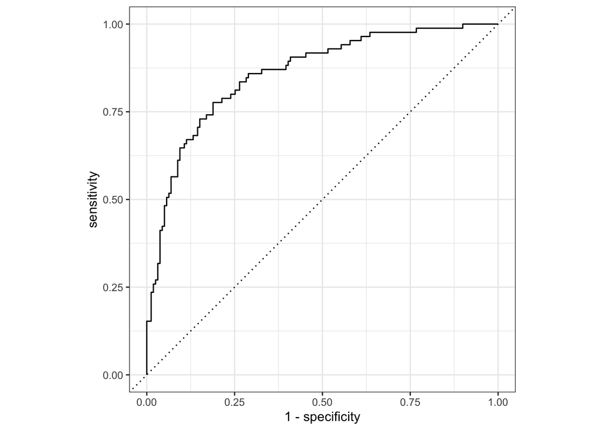

```r
# Plot ROC curve
telecom_results %>%
  roc_curve(truth = canceled_service, .pred_yes) %>%
  autoplot()
```

```r
# Plot ROC curve
telecom_results %>%
  roc_auc(truth = canceled_service, .pred_yes)
```

| .metric | .estimator | .estimate |
| --- | --- | --- |
| roc_auc | binary | 0.8588975 |